# Obtendo Dados

Esse notebook descreve o processo para obtenção das cotações das ações comercializadas na bolsa de valores de São Paulo (B3).

# Pacotes

A primeira escolha para obtenção dos dados seria o pacote `GetHFData`, mas o pacote não funciona mais desde o início de 2020:

> *2020-06-30 IMPORTANT: B3 closed the public access to the ftp site and, therefore, the package is not working. As far as I know, there is no expectation of any change in that status in the near future. I’m also not aware of any other source of HF data.*

Então vamos usar o `quantmod`:

> *quantmod is an R package that provides a framework for quantitative financial modeling and trading. It provides a rapid prototyping environment that makes modeling easier by removing the repetitive workflow issues surrounding data management and visualization.*

```r
library(quantmod)
```

# Quick Demo

Vamos obter as cotações da `VALE3`e dar uma olhada nos dados dos últimos 5 pregões.

```r
stock_code <- "VALE3.SA"
getSymbols(stock_code, src="yahoo")
```

```
VALE3.SA contains missing values. Some functions will not work if objects contain missing values in the middle of the series. Consider using na.omit(), na.approx(), na.fill(), etc to remove or replace them.
```

```
[1] "VALE3.SA"
```

```r
tail(VALE3.SA)
```

```
           VALE3.SA.Open VALE3.SA.High VALE3.SA.Low VALE3.SA.Close VALE3.SA.Volume
2020-09-11         60.05         62.30        59.84          61.95        46057000
2020-09-14         62.80         63.35        61.38          61.91        35710200
2020-09-15         62.71         63.65        62.15          62.60        32570600
2020-09-16         62.32         62.50        60.65          60.97        28843500
2020-09-17         60.40         62.42        60.11          62.08        31397500
2020-09-18         62.48         63.10        61.66          61.66        33143800
           VALE3.SA.Adjusted
2020-09-11             61.95
2020-09-14             61.91
2020-09-15             62.60
2020-09-16             60.97
2020-09-17             62.08
2020-09-18             61.66
```

É possível ver que o Yahoo nos retorna os dados de abertura, máxima, mínima, fechamento, volume e uma cotação “ajustada”.

Vamos plotar a série para ver como a cotação se comporta ao longo do tempo.

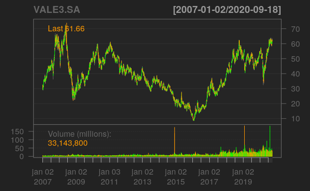

```r
chartSeries(VALE3.SA)
```

Esta é toda a série da cotação da Vale. Desde sua entrada na bolsa em 2007 até o último pregão realizado.